# CUNY SPS DATA 622 - Machine Learning and Big Data

Spring 2021 - Group 3 - Final

Maryluz Cruz, Amber Ferger, Tony Mei, and Charlie Rosemond

May 20, 2021

### R Packages

The `R` language is used to facilitate data modeling. The main `R` packages used for data wrangling, visualization, and graphics are listed below.

```r
# Required R packages
library(tidyverse)
library(kableExtra)
library(skimr)
library(corrplot)
library(e1071)
library(dummies)
library(caret)
library(gbm)
library(vip)
library(MASS)
library(ggplot2)
```

## Overview

This analysis employs a variety of algorithms to predict fetal health status using a cardiotocogram (CTG) dataset. Predicting fetal health, particularly suspect and pathological health statuses, is key for informing doctors in identifying appropriate interventions and intervention timelines. Analysis begins with exploratory data analysis (EDA) and preprocessing followed by a series of predictive models. It ends with an evaluation of model performance.

All references and a technical appendix of all R code are available at the end of this report.

**PROJECT SECTIONS**

### Exploratory Data Analysis (EDA)

EDA uses summary statistics and univariate and bivariate visualizations to summarize the CTG dataset, its response, and the initial set of possible features. This information will inform preprocessing of the dataset prior to modeling.

#### Dataset

Sourced from a 2000 research project and deidentified, the dataset consists of samples describing selected health characteristics of individual fetuses. It contains 2,126 samples and 22 total variables, including a target `fetal_health` with three classes: ‘Normal’, ‘Suspect’, and ‘Pathological’. The available features for modeling range from the fetal heart rate (FHR) baseline (`baseline_value`) to the number of prolonged decelerations per second (`prolonged_decelerations`) to varied characteristics of FHR distribution (`histogram_*`). All variables in the dataset are listed and described below.

*Dataset Descriptions*

| Variable | Description |
| --- | --- |
| baseline_value | Fetal heart rate (FHR) baseline (beats per minute) |
| accelerations | # of accelerations per second |
| fetal_movement | # of fetal movements per second |
| uterine_contractions | # of uterine contractions per second |
| light_decelerations | # of light decelerations per second |
| severe_decelerations | # of severe decelerations per second |
| prolonged_decelerations | # of prolonged decelerations per second |
| abnormal_short_var | % of time with abnormal short term variability |
| mean_short_var | Mean value of short term variability |
| perc_time_long_var | % of time with abnormal long term variability |
| mean_long_var | Mean value of long term variability |
| histogram_width | Width of FHR histogram |
| histogram_min | Minimum (low frequency) of FHR histogram |
| histogram_max | Maximum (high frequency) of FHR histogram |
| histogram_peaks | # of histogram peaks |
| histogram_zeroes | # of histogram zeroes |
| histogram_mode | Histogram mode |
| histogram_mean | Histogram mean |
| histogram_median | Histogram median |
| histogram_variance | Histogram variance |
| histogram_tendency | Histogram tendency |
| fetal_health | 1 (Normal), 2 (Suspect), 3 (Pathological) - TARGET |

#### Summary Statistics

**Expand for Basic Statistic Summary**

Data summary

| Name | df |
| --- | --- |
| Number of rows | 2126 |
| Number of columns | 22 |
| _______________________ |  |
| Column type frequency: |  |
| factor | 1 |
| numeric | 21 |
| ________________________ |  |
| Group variables | None |

**Variable type: factor**

| skim_variable | complete_rate | ordered | n_unique | top_counts |
| --- | --- | --- | --- | --- |
| fetal_health | 1 | TRUE | 3 | 1: 1655, 2: 295, 3: 176 |

**Variable type: numeric**

| skim_variable | complete_rate | mean | sd | p0 | p50 | p100 |
| --- | --- | --- | --- | --- | --- | --- |
| baseline_value | 1 | 133.30 | 9.84 | 106.0 | 133.0 | 160.00 |
| accelerations | 1 | 0.00 | 0.00 | 0.0 | 0.0 | 0.02 |
| fetal_movement | 1 | 0.01 | 0.05 | 0.0 | 0.0 | 0.48 |
| uterine_contractions | 1 | 0.00 | 0.00 | 0.0 | 0.0 | 0.01 |
| light_decelerations | 1 | 0.00 | 0.00 | 0.0 | 0.0 | 0.01 |
| severe_decelerations | 1 | 0.00 | 0.00 | 0.0 | 0.0 | 0.00 |
| prolonged_decelerations | 1 | 0.00 | 0.00 | 0.0 | 0.0 | 0.00 |
| abnormal_short_var | 1 | 46.99 | 17.19 | 12.0 | 49.0 | 87.00 |
| mean_short_var | 1 | 1.33 | 0.88 | 0.2 | 1.2 | 7.00 |
| perc_time_long_var | 1 | 9.85 | 18.40 | 0.0 | 0.0 | 91.00 |
| mean_long_var | 1 | 8.19 | 5.63 | 0.0 | 7.4 | 50.70 |
| histogram_width | 1 | 70.45 | 38.96 | 3.0 | 67.5 | 180.00 |
| histogram_min | 1 | 93.58 | 29.56 | 50.0 | 93.0 | 159.00 |
| histogram_max | 1 | 164.03 | 17.94 | 122.0 | 162.0 | 238.00 |
| histogram_peaks | 1 | 4.07 | 2.95 | 0.0 | 3.0 | 18.00 |
| histogram_zeroes | 1 | 0.32 | 0.71 | 0.0 | 0.0 | 10.00 |
| histogram_mode | 1 | 137.45 | 16.38 | 60.0 | 139.0 | 187.00 |
| histogram_mean | 1 | 134.61 | 15.59 | 73.0 | 136.0 | 182.00 |
| histogram_median | 1 | 138.09 | 14.47 | 77.0 | 139.0 | 186.00 |
| histogram_variance | 1 | 18.81 | 28.98 | 0.0 | 7.0 | 269.00 |
| histogram_tendency | 1 | 0.32 | 0.61 | -1.0 | 0.0 | 1.00 |

Summary statistics reveal useful information about the dataset. First, the dataset contains zero missing values. This completeness renders imputation, which can rest on tenuous assumptions, unnecessary. Second, beyond the categorical target `fetal_health`, all of the features are numeric, though their scales vary substantially. Thus centering and scaling could facilitate modeling. Third, many features display apparent rightward skew, which suggests additional transformation may be necessary as well. And fourth, the classes of `fetal_health` are highly imbalanced. The largest class, “Normal” (1), consists of 1,655 samples compared to 295 samples for “Suspect” (2) and 176 samples for “Pathological” (3).

#### Feature Distributions

Next comes visualization of the dataset features and their relations to the target `fetal_health`. The following two figures depict sets of feature-specific boxplots by class of `fetal_health`. Broadly, the boxplots reveal clear class-related differences in the distributions of the features.

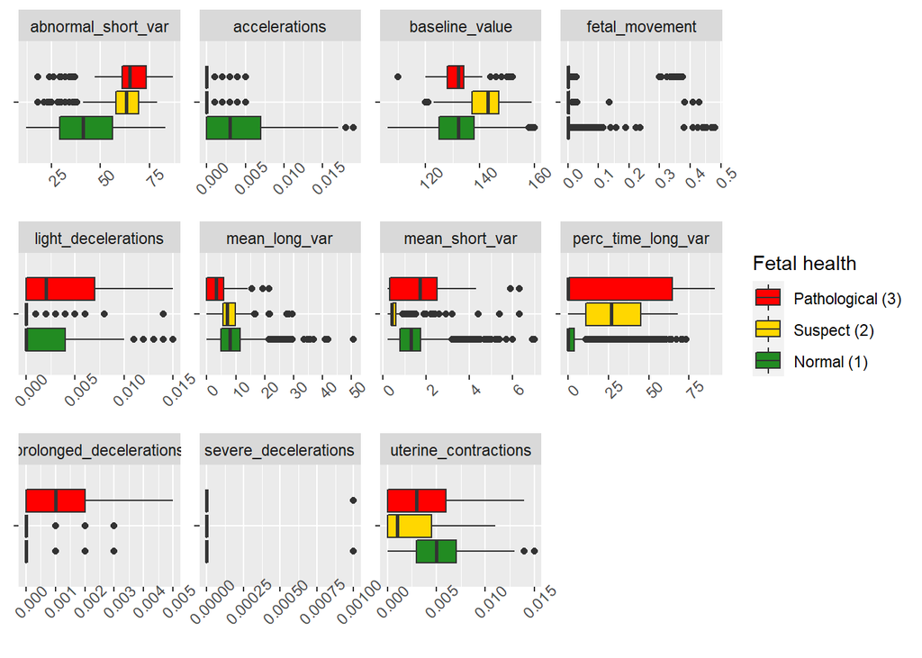

Feature boxplots by fetal health

The first set of plots focuses on the eleven non-histogram features: `baseline_value`, `accelerations`, `fetal_movement`, `uterine_contractions`, `light_decelerations`, `severe_decelerations`, `prolonged_decelerations`, `abnormal_short_var`, `mean_short_var`, `perc_time_long_var`, and `mean_long_var`. There are clear differences across classes of `fetal_health`. Notably, the IQRs of the distributions of `abnormal_short_var` and `accelerations` for the “Normal” class show minimal overlap with their counterparts for the other two classes. Features `light_decelerations` and `baseline_value` possess similar relationships for the “Suspect” class, as does `prolonged_decelerations` for the “Pathological” class. Skewness is common across features, particularly for `fetal_movement` and `severe_decelerations`, though level of skewness tends to vary by class within features (e.g., “Normal” for `perc_time_long_var`).

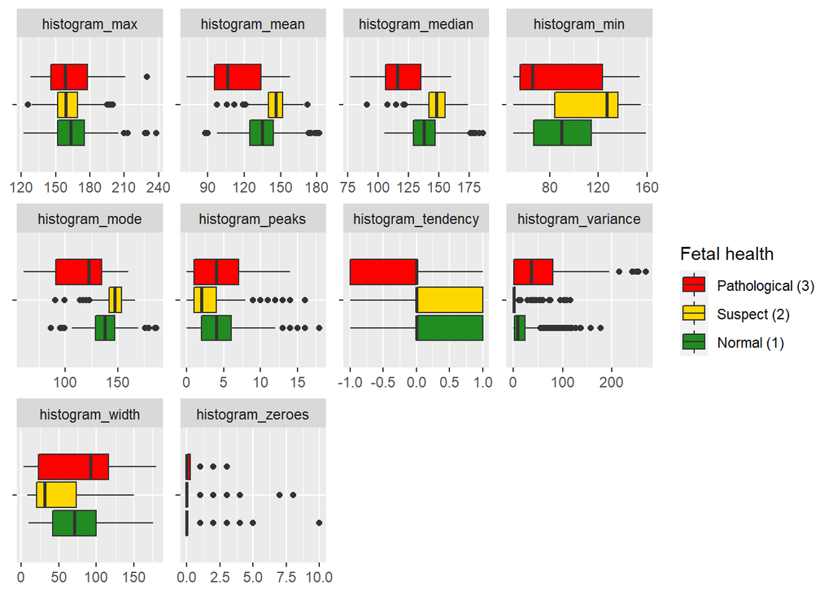

Feature boxplots by fetal health, continued

The second set of plots focuses on the ten histogram features: `histogram_width`, `histogram_min`, `histogram_max`, `histogram_peaks`, `histogram_zeroes`, `histogram_mode`, `histogram_mean`, `histogram_median`, `histogram_variance`, and `histogram_tendency`. Several observations jump out. First, the three measure of central tendency features show different distributions across classes of `fetal_health`, but those distributions are similar regardless of measure. Second, there is less skewness among this set of features, though it is still present and is substantial for `histogram_peaks`, `histogram_variance`, and `histogram_zeroes`; there are particular class differences in variance. And third, for `histogram_tendency`, the distribution for the “Pathological” class is predominantly negative versus the predominantly positive distributions for the “Normal” and “Suspect” classes.

#### Feature Correlations

The feature names and descriptions suggest that groups of features are correlated, which could pose problems of collinearity during modeling. Considering the marked differences in feature distributions by class of `fetal_health`, it is appropriate to calculate any correlations separately for each class. Further, across features and classes, distributions are typically skewed, which calls for the non-parametric Spearman’s rho. Below are correlation heat maps using Spearman’s rho for all features and by class of `fetal_health`.

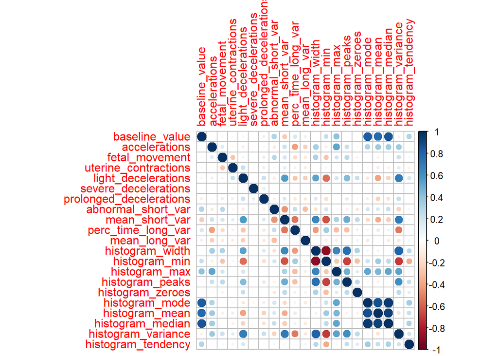

Spearman’s correlation heat map of features, Fetal health: Normal (1)

Several patterns stand out for the “Normal” class. Understandably, the measure of central tendency features are highly positively correlated with one another but also with `baseline_value`. Likewise, the histogram shape features show notably strong correlations, including the negative correlations between `histogram_min` and each of `histogram_width`, `histogram_peaks`, and `histogram_variance`, and the positive correlations between `histogram_width` and each of `histogram_max`, `histogram_peaks`, and `histogram_variance`. Other features with somewhat strong correlations across features are `light_decelerations` and `mean_short_var`.

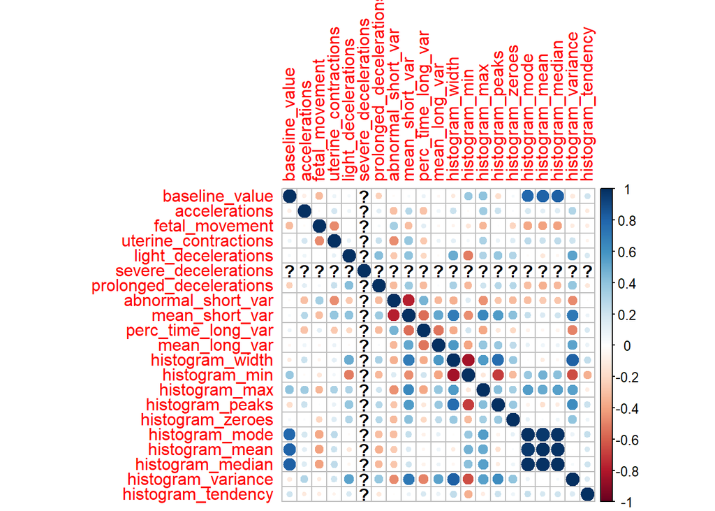

Spearman’s correlation heat map of features, Fetal health: Suspect (2)

The heat map for the “Suspect” class repeats the general “Normal” patterns but with higher correlation values. There are stronger relationships between the histogram shape features and the non-histogram features. Additionally, the question marks for `severe_decelerations` indicate that there are zero values for that feature for this class.

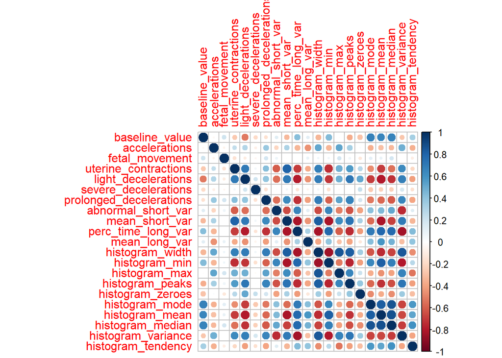

Spearman’s correlation heat map of features, Fetal health: Pathological (3)

The third heat map, for the “Pathological” class, continues the pattern of stronger correlations. Nearly all previously observed patterns are amplified, whether to the positive or the negative, for this class. A small set of features continues to show relatively weaker correlations, including `baseline_value` (aside from the measure of central tendency features), `accelerations`, `fetal_movement`, `severe_decelerations`, `mean_long_var`, `histogram_zeroes`, and `histogram_tendency`.

### Data Preprocessing

Some modeling methodologies require datasets that do not have missing values and are free of multicollinearity, outliers, and highly influential leverage points. Since the dataset has no null values, imputation is not necessary. The remaining issues are tackled in the following preprocessing code.

#### Skewness

Examining the skewness of each feature allows for a better understanding of the dataset at hand and can help to more easily identify features affected by outliers. Below are skewness statistics for each feature, with negative values reflecting left skewness and positive values reflecting right skewness. Larger values are associated with greater levels of skewness.

Two features show large skew greater than $\pm$ 5: `severe_decelerations` at approximately 17.33; and `fetal_movement` at approximately 7.80. Three additional features show skew greater than $\pm$ 3: `prolonged_decelerations` at approximately 4.32; `histogram_zeroes` at approximately 3.91; and `histogram_variance` at approximately 3.22. All positive, these values reflect the distributions depicted during EDA. They could respond favorably to transformation prior to modeling, though the Box-Cox transformation (results not shown) only negligibly affects the skewness.

|  | Skewness |
| --- | --- |
| baseline_value | 0.0202835 |
| accelerations | 1.2026931 |
| fetal_movement | 7.8004579 |
| uterine_contractions | 0.1590898 |
| light_decelerations | 1.7160127 |
| severe_decelerations | 17.3289771 |
| prolonged_decelerations | 4.3178655 |
| abnormal_short_var | -0.0118119 |
| mean_short_var | 1.6550013 |
| perc_time_long_var | 2.1919788 |
| mean_long_var | 1.3301189 |
| histogram_width | 0.3137915 |
| histogram_min | 0.1156207 |
| histogram_max | 0.5770473 |
| histogram_peaks | 0.8916264 |
| histogram_zeroes | 3.9147572 |
| histogram_mode | -0.9937740 |
| histogram_mean | -0.6501009 |
| histogram_median | -0.4777393 |
| histogram_variance | 3.2154316 |
| histogram_tendency | -0.3111925 |

#### Outlier Detection

Outliers are defined as any observations that lie outside 1.5 * IQR, where IQR (Inter Quartile Range) is the difference between the 75th and 25th quartiles of the feature values. Outliers appear as dots on box and whisker plots.

A closer examination of the `severe_decelerations` variable shows that there are only 2 values for this feature - 0 and 0.001. Only 7 records in the dataset have a non-zero value, but 6 of these are classified as Pathological fetal health. To retain this information, this feature is eliminated from outlier analysis.

Caps are placed on observations at their 5th and 95th percentiles for the remaining variables. Any data points that fall outside of this range are replaced with the capped values.

#### Collinearity

EDA found that strong correlations are present for each class of `fetal_health`. Spearman’s rank coefficient is used to check correlations once more with all samples, regardless of class. This new plot mimics the one for the “Normal” class on account of the notable imbalance in sample counts. Here again, the measure of central tendency features are highly positively correlated with one another and with `baseline_value`. There are also strong correlations, varying between positive and negative, between the histogram shape features. Others with somewhat strong correlations across features are `light_decelerations` and `mean_short_var`.

Additionally, three pairs of features have pair-wise correlation values above the 0.90 absolute threshold. For each pair, the feature with the higher mean absolute correlation is recommended for removal from the data set; these three features are `histogram_min`, `histogram_mean`, and `histogram_median`. They are removed prior to modeling.

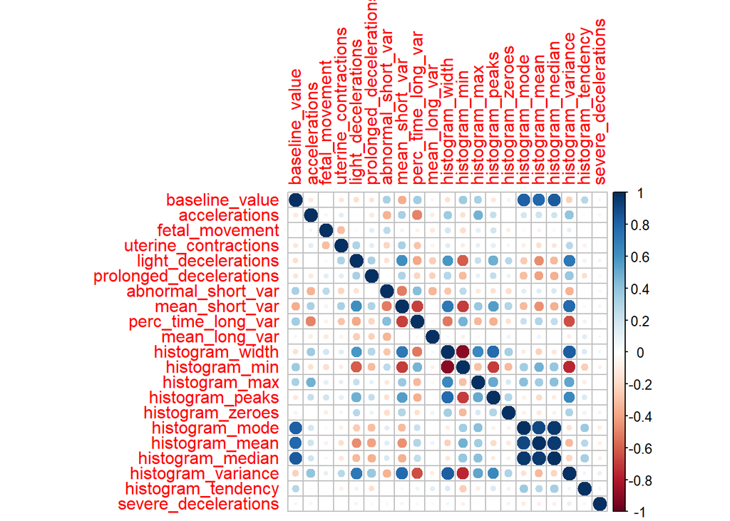

#### Train/Test Split

Lastly, the data set is split 70/30 into a training set and a test set. The latter will be held out for validation of the final models.

The resulting training and test sets have 1475 and 651 rows, respectively.

### Ordinal Logistic Regression

Ordinal Logistic Regression (OLR) is a classification method for problems with more than 2 *ordinal* outcomes. Since the outcome variable in this project, `fetal_health`, is progressive in nature, this method was chosen over a standard multinomial logistic regression, where classifications do not assume a numeric ordering.

It is important that the `fetal_health` outcome variable is explicitly defined as ordinal. Elimination of this step results in an analysis that is potentially meaningless. The `fetal_health`factor in this dataset is ordered from 1 - Normal, 2 - Suspect, and 3 - Pathological.

#### OLR Base Model

A baseline model that includes all features is developed. Specifying Hess=TRUE provides the observed information matrix from optimization. Similar to a standard logistic regression, the output of OLR includes the coefficients, standard errors, intercepts, and metrics (Residual Deviance and AIC). It also includes t-values, which need to be converted to p-values to identify features for model inclusion.

T-values are the model coefficients divided by their standard error (where standard error is an estimate of the variation). The larger the t-value, the greater the evidence *against* the null hypothesis, and ultimately, the more likely the feature should be included in the model. T-values and p-values are inextricably linked, and since p-values are used to identify features for inclusion, the t-values are converted. A summary of initial model features, including the coefficients and p-values is included in the table below.

```
##                                Value Std. Error      t value      p value
## baseline_value           1.618710479  0.7786186  2.078951791 3.762178e-02
## accelerations           -8.649541992  1.2046913 -7.179882398 6.977141e-13
## fetal_movement          -0.732117329  0.4437418 -1.649872326 9.896905e-02
## uterine_contractions    -2.229580195  0.3613449 -6.170226919 6.819206e-10
## light_decelerations     -1.529016490  0.5987776 -2.553563206 1.066269e-02
## prolonged_decelerations  5.394271702  0.5278990 10.218378501 1.640622e-24
## abnormal_short_var       4.329746225  0.5475717  7.907177143 2.632908e-15
## mean_short_var          -1.371684261  0.7715743 -1.777773287 7.544110e-02
## perc_time_long_var       1.057329838  0.3870188  2.731985790 6.295386e-03
## mean_long_var           -1.064813891  0.7708739 -1.381307556 1.671844e-01
## histogram_width         -1.561222257  0.8626423 -1.809814146 7.032461e-02
## histogram_max            3.468279738  0.8463747  4.097806260 4.170841e-05
## histogram_peaks          0.005320765  0.5683204  0.009362264 9.925301e-01
## histogram_zeroes        -0.223109933  0.4012522 -0.556034196 5.781875e-01
## histogram_mode          -2.624937244  0.9641524 -2.722533617 6.478344e-03
## histogram_variance       2.664573332  0.6439059  4.138140994 3.501312e-05
## histogram_tendency       0.715553212  0.4434007  1.613784418 1.065742e-01
## severe_decelerations     4.055847726  1.2708276  3.191501233 1.415355e-03
## 1|2                      2.689643797  0.7691247  3.497018935 4.704884e-04
## 2|3                      5.530234882  0.7973262  6.935975401 4.034278e-12
```

The last two rows in the output are the intercepts (or cutpoints) of the OLR. They represent where the outcome variable is cut to create the three groups of `fetal_health`. It is apparent by looking at the p-values that many features (like `histogram_peaks` and `histogram_zeroes`) do not warrant enough significance for inclusion in the final model.

#### OLR Improved Model

Backwards elimination using a p-value of less than 0.05 results in a final model that excludes the following features: `histogram_peaks`, `histogram_zeroes`, `mean_long_var`, `mean_short_var`, and `histogram_tendency`. Confidence intervals and proportional log-odds ratios are computed for the final OLR model.

```
##                                   OR        2.5 %       97.5 %
## baseline_value          4.610438e+00 1.029905e+00  20.45818246
## accelerations           2.533684e-04 2.255512e-05   0.00210013
## fetal_movement          4.096692e-01 1.754595e-01   0.93349482
## uterine_contractions    9.836939e-02 4.889797e-02   0.19439477
## light_decelerations     2.234842e-01 8.258704e-02   0.57999024
## prolonged_decelerations 2.189972e+02 8.378651e+01 610.45753520
## abnormal_short_var      1.160374e+02 4.565958e+01 312.07724146
## perc_time_long_var      4.298857e+00 2.303978e+00   8.07435726
## histogram_max           1.457852e+01 4.246393e+00  51.15954738
## histogram_mode          1.656304e-01 3.012074e-02   0.92963881
## histogram_variance      1.512956e+01 4.469471e+00  52.02717777
## severe_decelerations    3.933170e+01 4.532012e+00 879.48539675
## histogram_width         2.104377e-01 6.949437e-02   0.62313623
```

The proportional log-odds ratios can be interpreted similar to odds ratios from binary logistic regression models. In other words, we can interpret each variable as “for a one unit increase in variable XXX, the odds of fetal health moving from Normal to Suspect or Pathological are YYY times greater, given that the other variables in the model are held constant”.

It is important to note that the succession of the `fetal_health` variable from 1 (Normal) to 2 (Suspect) to 3 (Pathological) represents an overall **decrease** in the well-being of the child. This distinction is vital for proper interpretation of the proportional log-odds ratios.

As a gut check, these results make intuitive sense. For example, one would expect that the more fetal movement there is, the healthier the baby and the more severe decelerations there are, the unhealthier the baby.

#### OLR Performance

Predictions are made on the test set to evaluate model performance. Final performance is included in the summary below.

```
## Confusion Matrix and Statistics
##
##
## olr_preds   1   2   3
##         1 482  29   4
##         2  25  48  23
##         3   1  11  28
##
## Overall Statistics
##
##                Accuracy : 0.8571
##                  95% CI : (0.8279, 0.8831)
##     No Information Rate : 0.7803
##     P-Value [Acc > NIR] : 4.52e-07
##
##                   Kappa : 0.6005
##
##  Mcnemar's Test P-Value : 0.09655
##
## Statistics by Class:
##
##                      Class: 1 Class: 2 Class: 3
## Sensitivity            0.9488  0.54545  0.50909
## Specificity            0.7692  0.91474  0.97987
## Pos Pred Value         0.9359  0.50000  0.70000
## Neg Pred Value         0.8088  0.92793  0.95581
## Prevalence             0.7803  0.13518  0.08449
## Detection Rate         0.7404  0.07373  0.04301
## Detection Prevalence   0.7911  0.14747  0.06144
## Balanced Accuracy      0.8590  0.73010  0.74448
```

The overall accuracy of the model is 0.8571429.

### Support Vector Machine (SVM)

Support Vector Machine (SVM) is a supervised machine learning algorithm that can be used for classification or regression problems. Kernel is the technique used to transform ones data and then based on these transformations an optimal boundary is then found between the possible outputs. The data transformations are pretty complex, then separates your data based on the labels or outputs that have been defined.

SVM can be run using the e1071 package or the caret package. In the e1071 package the kernels are Linear, Radial, Polynomial or Sigimoid. In the caret package, the kernels are listed as svmLinear (for linear values), svmRadial (for non linear), and svmPoly (for nonlinear). When it is run within the svm function the kernals are listed differently in the in the e1071 it is listed under kernel, while in the caret package it is listed under method. For the purpose of this project, svmLinear will be used.

Before training the model, the trainControl() method is implemented. This will control all the computational overheads so that it can use the train() function provided by the caret package. The training method will train the data on different algorithms.

- The **method** parameter defines the re-sampling method.Repeated cross-validation is chosen for this model.
- The **number** parameter holds the number of re-sampling iterations.
- The **repeats** parameter contains the sets to compute for the repeated cross-validation.

#### SVM Base Model

A base SVM model is created for comparison purposes. Features are centered and scaled. The tuneLength parameter tells the algorithm to optimize training by using different default values for the main parameter. Predictions are made on the test set to evaluate model performance.

Overall accuracy of the base model on the test set is 0.8817204.

#### SVM Improved Model

To determine the ideal configuration for an optimized model, the tuneGrid parameter is used with a series of pre-defined Cost values between 0 and 5. Results are visualized in a plot of performance for each of the selected grid values.

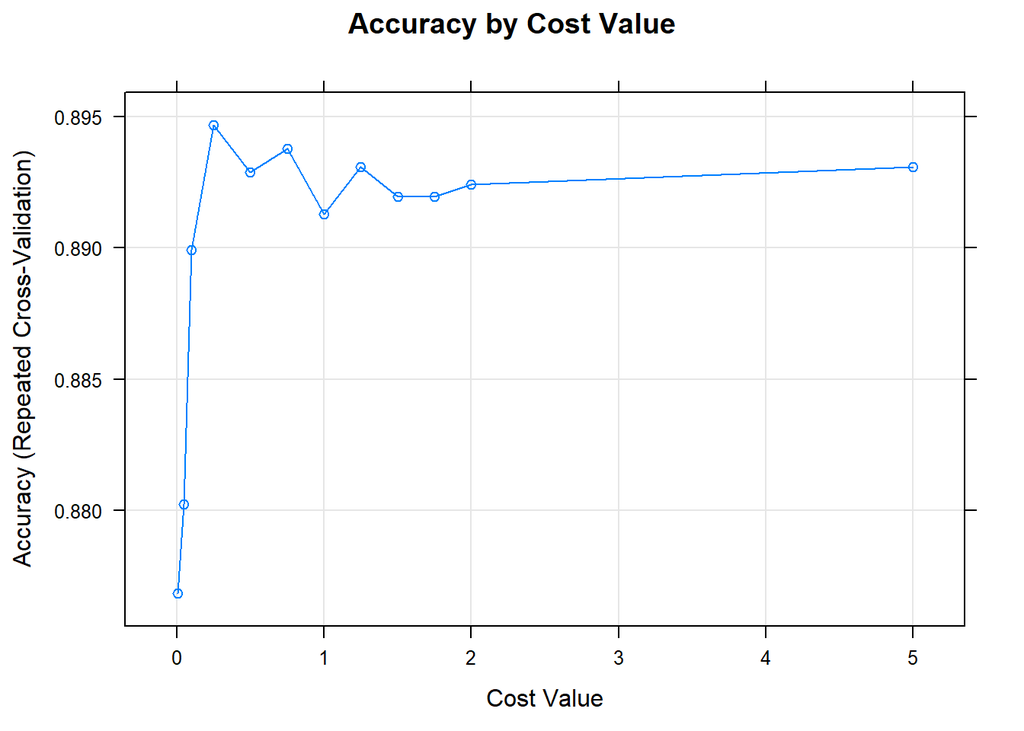

The final value used for the improved model is C = 0.25. Final predictions are made on the test set. Results are displayed in the table below.

```
## Confusion Matrix and Statistics
##
##
## svm_final_pred   1   2   3
##              1 482  22   7
##              2  23  62  17
##              3   3   4  31
##
## Overall Statistics
##
##                Accuracy : 0.8833
##                  95% CI : (0.8561, 0.9069)
##     No Information Rate : 0.7803
##     P-Value [Acc > NIR] : 7.642e-12
##
##                   Kappa : 0.6769
##
##  Mcnemar's Test P-Value : 0.02159
##
## Statistics by Class:
##
##                      Class: 1 Class: 2 Class: 3
## Sensitivity            0.9488  0.70455  0.56364
## Specificity            0.7972  0.92895  0.98826
## Pos Pred Value         0.9432  0.60784  0.81579
## Neg Pred Value         0.8143  0.95264  0.96085
## Prevalence             0.7803  0.13518  0.08449
## Detection Rate         0.7404  0.09524  0.04762
## Detection Prevalence   0.7849  0.15668  0.05837
## Balanced Accuracy      0.8730  0.81675  0.77595
```

Overall accuracy of the improved svm model on the test set is 0.8832565.

#### SVM Conclusion

SVlinear is chosen in this project because of the linear values of the dataset. Grid search was completed to identify the ideal cost value for the function, improving the model performance slightly from 0.8817204 to 0.8832565.

### Gradient Boosting Machines (GBM)

The gradient boosting machine (GBM) algorithm is a tree-based ensemble method. It builds an ensemble of weak learners–typically, decision trees of shallow depth–that learn from and improve on prior trees. This dependence across trees differs from the independent trees of the random forest algorithm. GBM have shown that a large number of weak learners can in aggregate produce high predictive performance.

GBM offer many hyperparameters for tuning as well as a choice of weak learner. This analysis uses decision trees and, for hyperparameters, focuses on the number of trees, or the total of trees to be fit by the algorithm; tree interaction depth, or the number of splits in each tree; and shrinkage, or the rate at which the algorithm descends the gradient. Per cursory research, the first three of these four appear to be the most common and also the most influential on model performance.

#### GBM Base Model

An initial GBM model serves as a baseline. It uses the default value for shrinkage (0.1) and compares numbers of trees of 50, 100, and 150 and depths of one, two, and three trees, respectively. Preprocessing consists of centering and scaling, and ten-fold cross-validation is repeated three times during training. Predictions are made on the test set to evaluate model performance.

Overall accuracy of the base model on the test set is 0.93702.

#### GBM Improved Model

GBM tuning starts from a grid of hyperparameter values. The possible numbers of trees (100, 500, 800 and 1000) are raised to account for lower possible shrinkage rates (0.01 and 0.05). Tree depth is also expanded to a maximum of seven. There are 24 possible combinations across the three hyperparameters.

A second GBM model adopts the tuning grid and maintains the same preprocessing (centering and scaling) and cross-validation (three-times, ten-fold) approaches. Training time is substantial.

Following grid search, and per accuracy, the optimal model features 800 trees, a depth of seven, and shrinkage of 0.05. Its training set accuracy and Kappa are approximately 0.95 and 0.85, respectively, which are both slight improvements over the baseline model. Feature importances are examined for the optimized model.

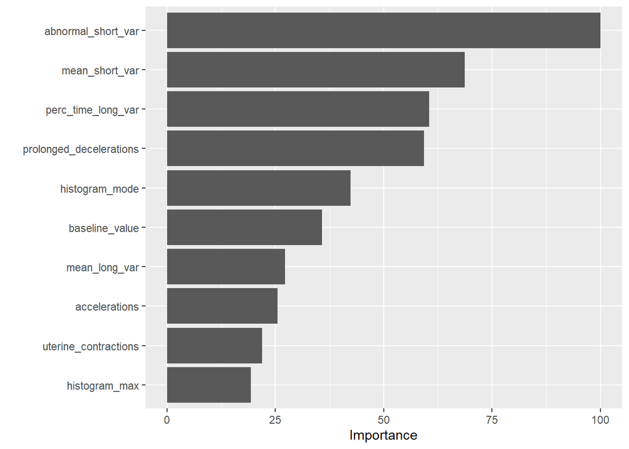

Regarding feature importance, `abnormal_short_var` is important in all trees where it informs splitting. The importance of `mean_short_var` is similar, at roughly 70.

It is interesting to note that the most important features in the model do not completely align with the findings from the ordinal logistic regression.

Particularly interesting is the `severe_decelerations` feature. In the OLR model, the proportional log-odds ratio was 39, indicating that for 1 unit increase, the odds of moving from Normal to Suspect or Pathological are 39 times greater. However, in the optimized GBM model, this feature doesn’t even appear in the top 10 factors!

Final predictions are made on the optimized GBM model. Results are included in the table below.

```
## Confusion Matrix and Statistics
##
##
## gbm2_pred   1   2   3
##         1 499  16   2
##         2   6  67   9
##         3   3   5  44
##
## Overall Statistics
##
##                Accuracy : 0.937
##                  95% CI : (0.9155, 0.9544)
##     No Information Rate : 0.7803
##     P-Value [Acc > NIR] : <2e-16
##
##                   Kappa : 0.8233
##
##  Mcnemar's Test P-Value : 0.1172
##
## Statistics by Class:
##
##                      Class: 1 Class: 2 Class: 3
## Sensitivity            0.9823   0.7614  0.80000
## Specificity            0.8741   0.9734  0.98658
## Pos Pred Value         0.9652   0.8171  0.84615
## Neg Pred Value         0.9328   0.9631  0.98164
## Prevalence             0.7803   0.1352  0.08449
## Detection Rate         0.7665   0.1029  0.06759
## Detection Prevalence   0.7942   0.1260  0.07988
## Balanced Accuracy      0.9282   0.8674  0.89329
```

### Random Forest (RF)

Random forest, is a collection of decision trees that are individual and create an ensemble. Each decision tree within the random forest has a class prediction and the class that has the most predictions becomes the designated prediction for the whole forest.

“The wisdom of crowds” is the fundamental concept of a random forest. A group of trees is needed to come together in order to classify the data to come up with a decision, which absorbs the flaws internally to come up with the best accuracy. It is important for a random forest for the trees to be uncorrelated so that the decision makers are not influenced by ones opinion.

Random forest will be used to see if it can accurately predict whether the `fetal_health` is either 1 - Normal, 2 - Suspect or 3 - Pathological. Since features in the dataset need to be uncorrelated the correlated features were already removed as part of the data preparation.

#### RF Base Model

First we run the model with the default values. The model includes the same trainControl as the previous models with the cross validation method, with 10 resampling iterations,and 3 repeats but with an addition of a grid search which is a randomized method. The model also includes a metric for accuracy, since achieving a higher accuracy is prevalent.

The base model gives an accuracy of 0.9262673. The balanced accuracy between the classes are approximately .9097 for Normal, .85031 for Suspect, and .90406 for Pathological.

#### Tuning of the RF Model

Next is to tune the model to see if a higher accuracy can be obtained by adding some tuning metrics. Some of the metrics that were added was the ‘Importance=true’ to obtain most important values. There are three metrics to note when it comes to tuning an RF model.

After getting the optimal values for each the final model consists of these parameters which are $m_{try}$ of 4, **maxnodes** of 25, and **ntree** of 800. The default model had an $m_{try}$ of 10.

#### Optimized RF Model

For the optimized RF model the node parameters will be removed, the tuneGrid will remain and it will be the default number of ntree’s which is 500.

```
## Confusion Matrix and Statistics
##
##           Reference
## Prediction   1   2   3
##          1 500  22   3
##          2   6  62   8
##          3   2   4  44
##
## Overall Statistics
##
##                Accuracy : 0.9309
##                  95% CI : (0.9086, 0.9491)
##     No Information Rate : 0.7803
##     P-Value [Acc > NIR] : < 2e-16
##
##                   Kappa : 0.8016
##
##  Mcnemar's Test P-Value : 0.01361
##
## Statistics by Class:
##
##                      Class: 1 Class: 2 Class: 3
## Sensitivity            0.9843  0.70455  0.80000
## Specificity            0.8252  0.97513  0.98993
## Pos Pred Value         0.9524  0.81579  0.88000
## Neg Pred Value         0.9365  0.95478  0.98170
## Prevalence             0.7803  0.13518  0.08449
## Detection Rate         0.7680  0.09524  0.06759
## Detection Prevalence   0.8065  0.11674  0.07680
## Balanced Accuracy      0.9047  0.83984  0.89497
```

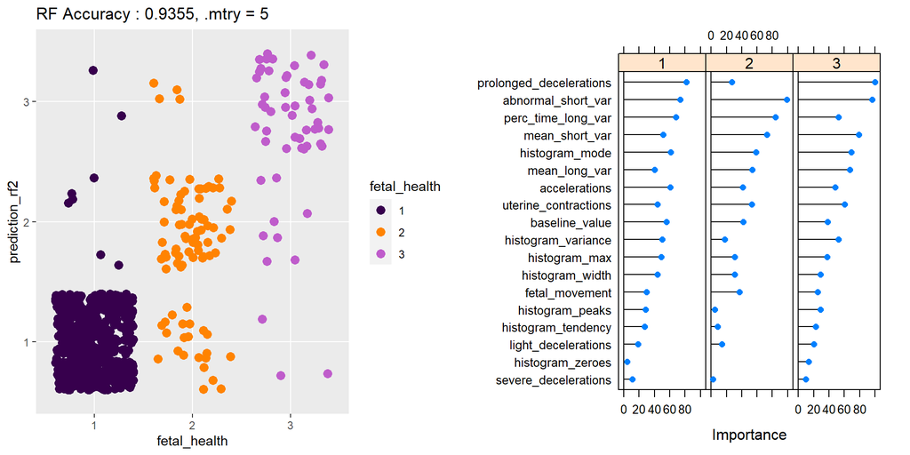

The varImp so that we can see the important features of the random forest in order to see if it compares to the Ordinal Logistic Regression model. Looking at the importance levels once can see that `prolonged_decelerations` is considered an important feature for Normal and Pathological class but not for Suspect class. `abnormal_short_var` is the important feature for Suspect. It is interesting though that ‘accelerations’ is not considered important in comparison to the OLR model.

#### RF Conclusion

The optimized model with the removal of nodes ended up being the optimized model, but it was a slight increase from the base model it went from 0.9262673 to 0.9308756. Although one may try to find the most optimized model by trying find the best parameters it may not always be the best model depending on the dataset. The best parameters to use for this model was $m_{try}$ and .ntree of the default number of 500. Since the accuracy is somewhat high one can use random forest in order to predict `fetal_health`.

### Model Comparison

Predicting fetal health is important in determining the appropriate course of action for a doctor to take. Successful prediction of **suspect** and **pathological** fetal health status can aid in the development of intervention timelines.

Although model accuracy is often used as a means of comparing models, since we are primarily concerned with properly identifying less healthy babies, it is important that the selected metrics gauge the performance of the models at the *classification level*. This is particularly important in this project, as the classes are drastically imbalanced.

In addition to a raw accuracy comparison, we will also use the following metrics to determine the best model:

- **Prevalence**: This measure shows us how often the positive class occurs in the sample. The data set is highly imbalanced, and this measure captures that.
- **Detection Rate**: This measure shows us the number of correct positive class predictions made as a proportion of all of the predictions made. In a perfect classifier, this number matches the Prevalence.
- **Sensitivity (Recall)**: This measure shows the proportion of the positive class that were correctly identified.

#### Model Accuracy

A comparison of the model accuracy across the 4 methods is shown below:

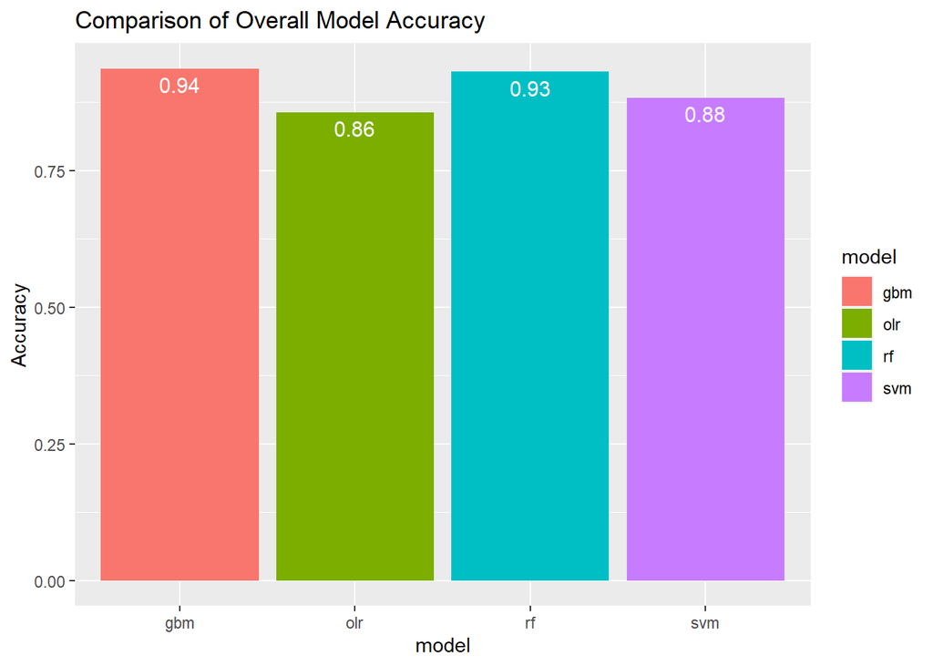

GBM performs the best, followed by Random Forest, then SVM, and finally OLR.

#### Class Prevalence

All models have the same class prevalence because the same training and test sets were used. We know from the EDA that the dataset is imbalanced. Visualizing the prevalence gives us a better idea of the proportion of each class in the test set:

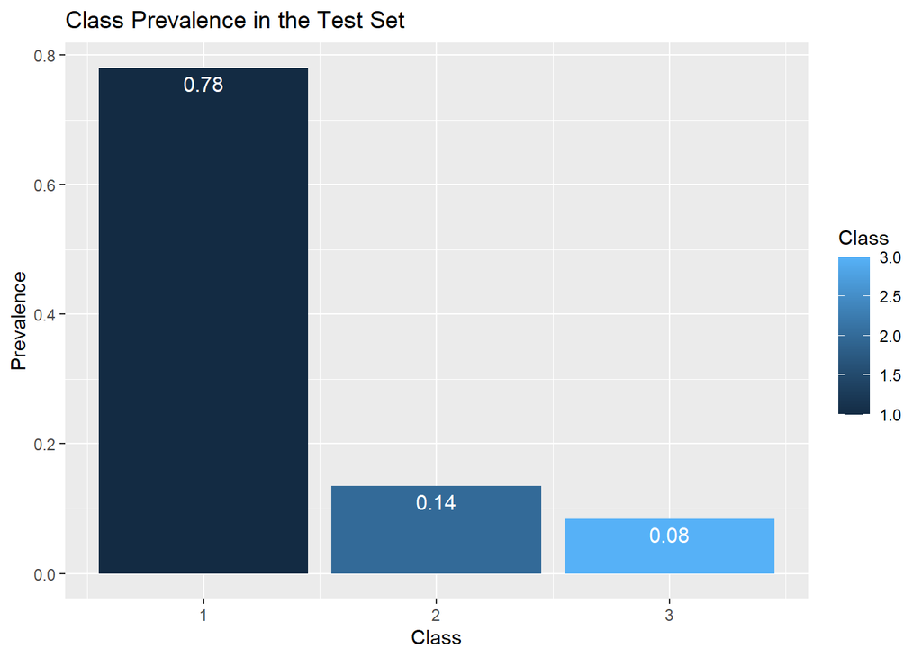

The prevalence can be used in combination with the Detection Rate to understand what portion of each class that the models correctly identified. In the following figure, predictions are broken out by prevalence at the class level per model. The blue area represents the portion of the class that was identified correctly. The pink area represents the portion of the class that was missed.

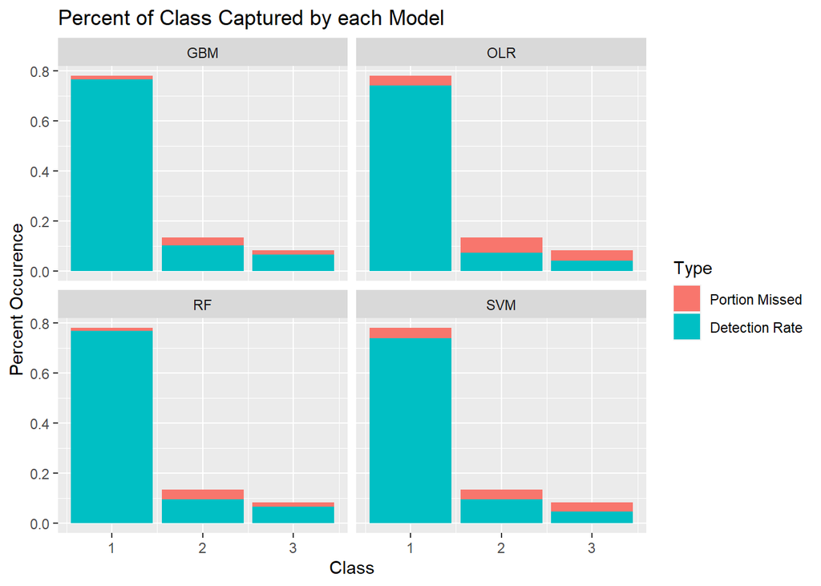

Out of the four models, OLR performs the worst on predicting Suspect and Pathological fetal health statuses.

#### Model Sensitivity

A comparison of model sensitivity for each of the three classes is shown below. It is important that the sensitivity for classes 2 (Suspect) and 3 (Pathological) are high, as these are the statuses that are more important to predict correctly.

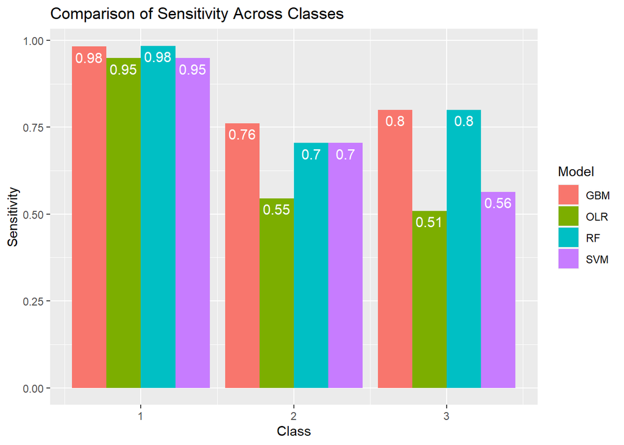

GBM performs best across the board, while OLR performs the worst. Some things to note:

- All models perform well when predicting Normal Fetal Health.
- GBM, SVM, and Random Forest perform worse when predicting Suspect Fetal Health, but significanly better then OLR.
- Both SVM and OLR perform poorly when predicting Pathological Fetal Health. GBM and Random Forest perform similarly.

### Conclusions and Future Work

Overall, the GBM model has the best performance with 94% Accuracy, and 98%, 76%, and 80% recall for Normal, Suspect, and Pathological statuses. Regarding future work, over- or under- sampling would create a more balanced dataset that could likely improve the overall metrics for the dataset, especially for the Ordinal Linear Regression Model. Additionally, including combination features could yield some interesting insights into the data, and potentially increase overall recall. Finally, this work could be expanded to include PCA for feature consolidation and reduction.

### Works Cited

https://www.kaggle.com/andrewmvd/fetal-health-classification

Ayres de Campos et al. (2000). *SisPorto 2.0 A Program for Automated Analysis of Cardiotocograms*. J Matern Fetal Med 5:311-318

Boehmke, B. (2018). *Gradient boosting machines*. UC Business Analytics R Programming Guide. Accessed May 15, 2021 from http://uc-r.github.io/gbm_regression.

Kumar Das, S. (2020). *Random Forest Classification explained in detail and developed in R*. TechTarget, Inc. Accessed May 2021 from https://www.datasciencecentral.com/profiles/blogs/random-forest-classification-explained-in-detail-and-developed-in.

Kuhn, M. (2019). *The caret package*. Accessed May 15, 2021, from https://topepo.github.io/caret/.

*R Random Forest Tutorial with Example*. Guru99. Accessed May 2021 from https://www.guru99.com/r-random-forest-tutorial.html.

Rashkiany, H. (2020). *Support Vector Machine In R: Using SVM To Predict Heart Diseases*. Edureka. Accessed May 2021 from www.edureka.co/blog/support-vector-machine-in-r/.

### Code Appendix

The code chunks below represent the R code called in order during the analysis. These are reproduced in the appendix for review and comment.

```r
df <- read_csv('https://raw.githubusercontent.com/chrosemo/DATA622-Group3-Final/main/fetal_health.csv')
df <- df %>% rename(baseline_value = 'baseline value',
                    prolonged_decelerations = 'prolongued_decelerations',
                    abnormal_short_var = 'abnormal_short_term_variability',
                    mean_short_var = 'mean_value_of_short_term_variability',
                    perc_time_long_var = 'percentage_of_time_with_abnormal_long_term_variability',
                    mean_long_var = 'mean_value_of_long_term_variability',
                    histogram_peaks = 'histogram_number_of_peaks',
                    histogram_zeroes = 'histogram_number_of_zeroes') %>%
             mutate(fetal_health = as.factor(fetal_health))

# order the dependent variable
df$fetal_health = factor(df$fetal_health, levels = c("1", "2", "3"), ordered = TRUE)
```

```r
skim(df) %>% dplyr::select(-n_missing, -numeric.p25, -numeric.p75, -numeric.hist)
```

```r
df %>%
  dplyr::select(baseline_value:mean_long_var, fetal_health) %>%
  gather(key = 'variable', value = 'value', -fetal_health) %>%
  ggplot(aes(x = '', y = value, fill = fetal_health)) +
    facet_wrap(~ variable, scales = 'free') +
    geom_boxplot() +
    coord_flip() +
    labs(x = NULL, y = NULL) +
    theme(axis.text.x = element_text(angle = 45)) +
    scale_fill_manual(name = 'Fetal health',
                      guide = guide_legend(reverse=TRUE),
                      labels = c('Normal (1)', 'Suspect (2)', 'Pathological (3)'),
                      values = c('forestgreen', 'gold', 'red'))
```

```r
df %>%
  dplyr::select(histogram_width:histogram_tendency, fetal_health) %>%
  gather(key = 'variable', value = 'value', -fetal_health) %>%
  ggplot(aes(x = '', y = value, fill = fetal_health)) +
    facet_wrap(~ variable, scales = 'free') +
    geom_boxplot() +
    coord_flip() +
    labs(x = NULL, y = NULL) +
    scale_fill_manual(name = 'Fetal health',
                      guide = guide_legend(reverse=TRUE),
                      labels = c('Normal (1)', 'Suspect (2)', 'Pathological (3)'),
                      values = c('forestgreen', 'gold', 'red'))
```

```r
corrplot(cor(df %>%
               filter(fetal_health == 1) %>%
               dplyr::select(-fetal_health),
             method = 'spearman'))
```

```r
corrplot(cor(df %>%
               filter(fetal_health == 2) %>%
               dplyr::select(-fetal_health),
             method = 'spearman'))
```

```r
corrplot(cor(df %>%
               filter(fetal_health == 3) %>%
               dplyr::select(-fetal_health),
             method = 'spearman'))
```

```r
knitr::kable(sapply(df[,-22], skewness), col.names = c("Skewness"))
```

```r
no_target <- subset(df, select = c(-fetal_health, -severe_decelerations))
```

```r
# identifying 5th and 95th percentiles per column
low5 <- apply(no_target, 2, quantile, prob = 0.05)
up95 <- apply(no_target, 2, quantile, prob = 0.95)

# for each column, replace outliers with upper 95% value or lower 5% value
for (i in seq_along(no_target)) {
  no_target[,i][no_target[,i] < low5[i]] <- low5[i]
  no_target[,i][no_target[,i] > up95[i]] <- up95[i]
}

# adding back in severe decelerations and fetal health
df <- cbind(no_target, severe_decelerations = df$severe_decelerations, fetal_health=df$fetal_health)
```

```r
corr <- cor(df %>% dplyr::select(-fetal_health), method = "spearman")
corrplot::corrplot(corr)
```

```r
df_clean <- as.data.frame(df %>% dplyr::select(-c('histogram_min', 'histogram_mean', 'histogram_median')))
```

```r
# min/max normalization
min_max_norm <- function(x) {
    (x - min(x)) / (max(x) - min(x))
}

# normalized data
df_normalized <- as.data.frame(lapply(df_clean %>% dplyr::select(-fetal_health), min_max_norm))

df_clean <- cbind(df_normalized, fetal_health = df_clean$fetal_health)
```

```r
set.seed(525)
which_train <- sample(x = c(TRUE, FALSE),
                      size = nrow(df_clean),
                      replace = TRUE,
                      prob = c(0.7, 0.3))
train_set <- df_clean[which_train, ]
test_set <- df_clean[!which_train, ]
```

```r
train_set2 <- train_set
test_set2 <- test_set

olr_model <- polr(fetal_health ~ ., data = train_set2, Hess=TRUE)
```

```r
ctable <- coef(summary(olr_model))
p <- pnorm(abs(ctable[, "t value"]), lower.tail = FALSE) * 2
ctable <- cbind(ctable, "p value" = p)
ctable
```

```r
olr_model_final <- polr(fetal_health ~ baseline_value + accelerations + fetal_movement +
                    uterine_contractions + light_decelerations + prolonged_decelerations +
                    abnormal_short_var + perc_time_long_var +
                    histogram_max + histogram_mode + histogram_variance +
                    severe_decelerations + histogram_width ,
                  data = train_set2, Hess=TRUE)

olr_ci <- confint(olr_model_final)
olr_or <- coef(olr_model_final)
exp(cbind(OR = olr_or, olr_ci))
```

```r
olr_preds <- predict(olr_model_final, newdata = test_set2)
olr_conf <- confusionMatrix(table(olr_preds, test_set2$fetal_health))
olr_accuracy <- olr_conf$overall['Accuracy']
olr_final_metrics <- as.data.frame(olr_conf$byClass[,c(1,8,9)]) %>%
  mutate(Model = 'OLR',
         Class = row_number())
olr_conf
```

```r
trctrl <- trainControl(method = "repeatedcv", number = 10, repeats = 3)
```

```r
set.seed(525)
svm_Linear <- train(fetal_health ~., data = train_set,
                    method = "svmLinear",
                    trControl=trctrl,
                    preProcess = c("center", "scale"),
                    tuneLength = 10)

svm_base_pred <- predict(svm_Linear, newdata = test_set)
svm_conf1 <- confusionMatrix(table(svm_base_pred, test_set$fetal_health))
svm_acc1 <- svm_conf1$overall['Accuracy']
```

```r
set.seed(525)
grid <- expand.grid(C = c(0,0.01, 0.05, 0.1, 0.25, 0.5, 0.75, 1, 1.25, 1.5, 1.75, 2, 5))
svm_Linear_Grid <- train(fetal_health ~., data = train_set, method = "svmLinear",
                         trControl=trctrl,
                         preProcess = c("center", "scale"),
                         tuneGrid = grid,
                         tuneLength = 10)
plot(svm_Linear_Grid,
     main = "Accuracy by Cost Value",
     xlab = 'Cost Value')
```

```r
set.seed(525)
svm_final_pred <- predict(svm_Linear_Grid, newdata = test_set)
svm_conf2 <- confusionMatrix(table(svm_final_pred, test_set$fetal_health))
svm_acc2 <- svm_conf2$overall['Accuracy']
svm_final_metrics <- as.data.frame(svm_conf2$byClass[,c(1,8,9)]) %>%
  mutate(Model = 'SVM',
         Class = row_number())

svm_conf2
```

```r
set.seed(525)
gbm1 <- train(x = train_set[,-19],
                           y = train_set[,19],
                           method = "gbm",
                           preProcess = c('center', 'scale'),
                           trControl = trctrl,
                           verbose = FALSE)


gbm1_pred <- predict(gbm1, newdata = test_set)
gbm_conf1 <- confusionMatrix(table(gbm1_pred, test_set$fetal_health))
gbm_acc1 <- gbm_conf1$overall['Accuracy']
```

```r
set.seed(525)

#grid <- expand.grid(.interaction.depth = c(2, 5, 7),
#                    .n.trees = c(100, 500, 800, 1000),
#                    .shrinkage = c(0.01, 0.05),
#                    .n.minobsinnode = 10)

#gbm2 <- train(x = train_set[,-19],
#                           y = train_set[,19],
#                           method = "gbm",
#                           tuneGrid = grid,
#                           preProcess = c('center', 'scale'),
#                           trControl = trctrl,
#                           verbose = FALSE)
```

```r
set.seed(525)
grid_opt <- expand.grid(.interaction.depth = 7,
                    .n.trees = 800,
                    .shrinkage = 0.05,
                    .n.minobsinnode = 10)
gbm_opt <- train(x = train_set[,-19],
                           y = train_set[,19],
                           method = "gbm",
                           tuneGrid = grid_opt,
                           preProcess = c('center', 'scale'),
                           trControl = trctrl,
                           verbose = FALSE)

vip(gbm_opt)
```

```r
gbm2_pred <- predict(gbm_opt, newdata = test_set)
gbm_conf2 <- confusionMatrix(table(gbm2_pred, test_set$fetal_health))
gbm_acc2 <- gbm_conf2$overall['Accuracy']
gbm_final_metrics <- as.data.frame(gbm_conf2$byClass[,c(1,8,9)]) %>%
  mutate(Model = 'GBM',
         Class = row_number())

gbm_conf2
```

```r
set.seed(525)
# Define the control
trControl <- trainControl(method = "repeatedcv", number = 10, repeats = 3)

# Run the model
rf_default <- train(fetal_health~.,
    data = train_set,
    method = "rf",
    metric = "Accuracy",
    trControl = trControl)
## print(rf_default)
```

```r
prediction_rf1 <-predict(rf_default, test_set)
rf_conf1<-confusionMatrix(prediction_rf1, test_set$fetal_health)
rf_acc1 <- rf_conf1$overall['Accuracy']
##rf_conf1
```

```r
set.seed(525)
tuneGrid = expand.grid(.mtry=c(2:15))
op_rf <- train(fetal_health~.,
    train_set,
    method = "rf",
    metric = "Accuracy",
    tuneGrid = tuneGrid,
    trControl = trControl,
    importance = TRUE,
    ntree = 500)

##print(op_rf)
```

```r
prediction_rf2 <-predict(op_rf, test_set)
rf_conf2<-confusionMatrix(prediction_rf2, test_set$fetal_health)
rf_acc2 <- rf_conf2$overall['Accuracy']
rf_final_metrics <- as.data.frame(rf_conf2$byClass[,c(1,8,9)]) %>%
  mutate(Model = 'RF',
         Class = row_number())
```

```r
p2= plot(varImp(op_rf, scale = TRUE))

gridExtra::grid.arrange(p1,p2, ncol=2)
```

```r
prevalence <- all_metrics %>%
  dplyr::select(Prevalence, Class) %>%
  distinct()

ggplot(prevalence, aes(x = Class, y = Prevalence, fill = Class)) +
  geom_bar(stat="identity") +
  ggtitle('Class Prevalence in the Test Set') +
  geom_text(aes(label = round(Prevalence,2)) ,
            colour = "white", size = 4,
            vjust = 1.5, position = position_dodge(.9))
```

```r
portion_missed <- all_metrics %>%
  mutate(`Portion Missed` = Prevalence - `Detection Rate`) %>%
  dplyr::select(-Sensitivity, -Prevalence)

portion_missed <- gather(portion_missed, type, rate, c(`Detection Rate`, `Portion Missed`))

ggplot(portion_missed, aes(x = Class,
                           y = rate,
                           fill = factor(type,
                                         levels=c("Portion Missed", "Detection Rate")))) +
  geom_bar(position = "stack", stat = "identity") +
  labs(fill = 'Type',
       y = 'Percent Occurence',
       title = 'Percent of Class Captured by each Model') +
  facet_wrap( ~ Model)
```

```r
all_metrics <- rbind(olr_final_metrics, svm_final_metrics, gbm_final_metrics, rf_final_metrics )
all_accuracies <- as.data.frame(rbind(olr = olr_accuracy, svm = svm_acc2, gbm = gbm_acc2, rf=rf_acc2 ))
all_accuracies$model <- rownames(all_accuracies)
ggplot(all_accuracies, aes(x = model, y = Accuracy, fill = model)) +
  geom_bar(stat="identity") +
  ggtitle('Comparison of Overall Model Accuracy') +
  geom_text(aes(label = round(Accuracy,2)) ,
            colour = "white", size = 4,
            vjust = 1.5, position = position_dodge(.9))
```

```r
ggplot(all_metrics %>% dplyr::select(-Prevalence, -`Detection Rate`),
       aes(x = Class, y = Sensitivity, fill = Model)) +
  geom_col(position = "dodge") +
  ggtitle('Comparison of Sensitivity Across Classes') +
  geom_text(aes(label = round(Sensitivity,2)) ,
            colour = "white", size = 4,
            vjust = 1.5, position = position_dodge(.9))
```